# Species interaction study

Molly Wilson

2025-06-10

# Data processing

Generating dataframe to determine growth rates and survival for each fragment

```r
weights <- read_excel(here("spp_interaction_exp", "data_raw", "Species interaction data.xlsx"),
                  sheet = "Buoyant weights") %>%
  clean_names() %>%
  mutate(type = case_when(table %in% c("C1", "C2") ~ "Control",
                          table %in% c("T1", "T2") ~ "Treatment"))

performance <- weights %>%
  filter(is.na(partial_death) | partial_death != "with") %>% # remove measurements that include dead tissue weight
  filter(!is.na(id)) %>%
  mutate(buoy_wght_g = rowMeans(across(starts_with("buoy_wght_")), na.rm = TRUE), # taking mean of measurements
         adj_wght_g = buoy_wght_g/(1-density_seawater_kg_m3/1000/2.94), # calculating adjusted masses
         month = round(time_length(interval(ymd("2025-02-27"), ymd(date)), "months"))) %>% # creating variable for number of months since inception
  group_by(id, month) %>%
  slice_max(date, n = 1, with_ties = FALSE) %>% # keeping the most recent measurement set within each month (some fragments were replaced during initial month so had multiple measurements)
  ungroup() %>%
  select(id, month, condition, adj_wght_g) %>%
  pivot_wider(id_cols = id,
              names_from = month,
              values_from = c(adj_wght_g, condition),
              names_sep = "_mo") %>%
  mutate(across(starts_with("adj"), ~ ifelse(is.nan(.), NA, .)),
         across(starts_with("condition"), ~ ifelse(is.na(.), "dead", .)), # any absent values are considered dead unless specified otherwise
         growth_rate_mo3 = (adj_wght_g_mo3 - adj_wght_g_mo0) / adj_wght_g_mo0, # growth rate from month 0 to 3
         growth_rate_mo7 = (adj_wght_g_mo7 - adj_wght_g_mo0) / adj_wght_g_mo0, # growth rate from month 0 to 7
         survival_mo3 = if_else(condition_mo3 == "alive", 1, 0), # survival (binary) at month 3
         survival_mo7 = if_else(condition_mo7 == "alive", 1, 0), # survival (binary) at month 7
         treatment = case_when(substr(id, 1, 1) == "C" ~ "Control",
                          substr(id, 1, 1) == "T" ~ "Treatment"),
         table = substr(id, 1, 2),
         genotype = substr(id, 4, 5)) %>%
  filter(!if_any(starts_with("condition"), ~ str_detect(., "missing"))) %>% # exclude any explicitly missing fragments
  select(id, treatment, table, genotype, wght_mo0 = adj_wght_g_mo0, growth_rate_mo3, growth_rate_mo7, survival_mo3, survival_mo7)

# look for outliers
# ggplot(performance, aes(x = growth_rate_mo7)) +
#   geom_histogram()

# remove outliers
performance <- performance %>%
  filter(growth_rate_mo7 < 2.5 | is.na(growth_rate_mo7))

datatable(performance,
          rownames = FALSE)
```

| id | treatment | table | genotype | wght_mo0 | growth_rate_mo3 | growth_rate_mo7 | survival_mo3 | survival_mo7 |
| --- | --- | --- | --- | --- | --- | --- | --- | --- |
| C1A24.1 | Control | C1 | 24 | 15.25825050220448 | 0.3387018815994996 |  | 1 | 0 |
| C1A24.2 | Control | C1 | 24 | 10.77383840755524 | 1.064300393869622 | 1.659857930550032 | 1 | 1 |
| C1A25.1 | Control | C1 | 25 | 7.347890741175551 | 0.4737463175207201 | 0.1958933567316206 | 1 | 1 |
| C1A25.2 | Control | C1 | 25 | 19.123946675015 | 0.2415269395002966 |  | 1 | 0 |
| C1B24.1 | Control | C1 | 24 | 19.97787691424695 | 0.1250202978455627 |  | 1 | 0 |
| C1B24.2 | Control | C1 | 24 | 29.85687824476272 | 0.1776019261015037 | 0.4874551824858941 | 1 | 1 |
| C1B25.1 | Control | C1 | 25 | 7.920586470480812 | 0.482033845356517 |  | 1 | 0 |
| C1B25.2 | Control | C1 | 25 | 8.079100466984947 | 0.6363940288777579 | 1.472637370035565 | 1 | 1 |
| C1C24.1 | Control | C1 | 24 | 11.55618168062404 | 0.3894607587289042 | 0.6893803329421676 | 1 | 1 |
| C1C24.2 | Control | C1 | 24 | 15.15598340768569 | 0.1477832864876939 |  | 1 | 0 |

[output cut: 110 more lines]

# Growth rates

- Tested both growth rates at midpoint and end point, models of end point had higher predictive power

## Visualization

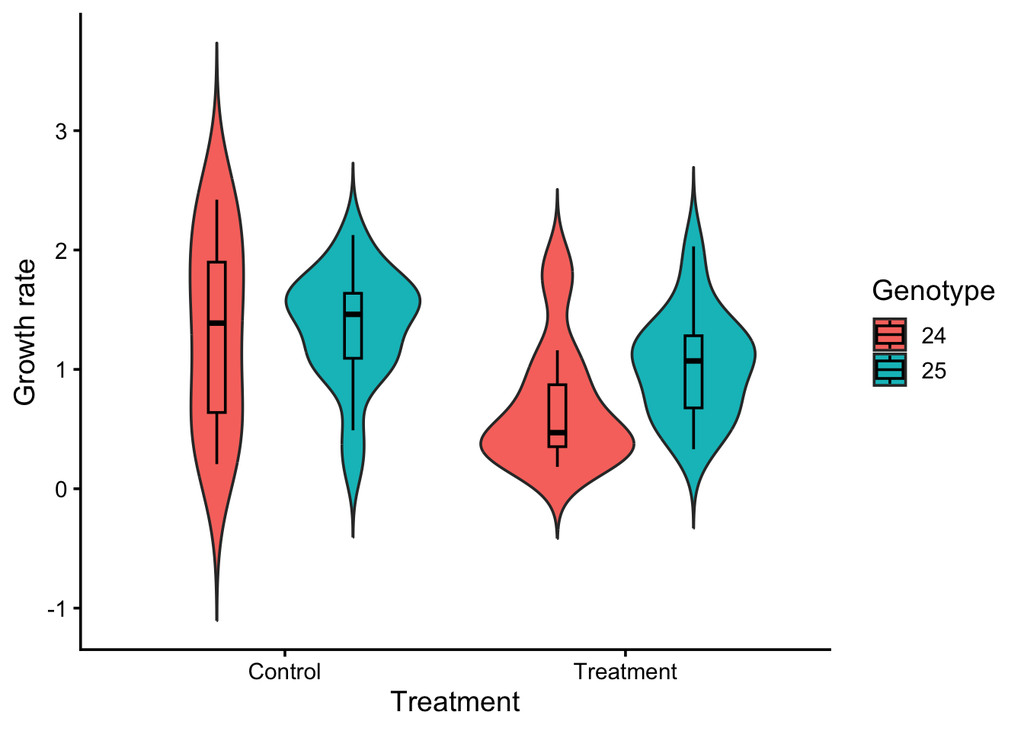

```r
ggplot(performance %>%
         filter(survival_mo7 == "1"),
       aes(x = treatment, y = growth_rate_mo7, fill = genotype)) +
  geom_violin(position = position_dodge(width = 0.8), trim = FALSE) +
  geom_boxplot(width = 0.1, position = position_dodge(width = 0.8), outlier.shape = NA, color = "black", alpha = 0.3) +
  labs(x = "Treatment",
       y = "Growth rate",
       fill = "Genotype") +
  theme_classic(base_size = 14)
```

## Models

#### Structure

Using mixed effects model with treatment and genotype as fixed effects and table as nested random effect (because table is a replicate within treatment)

```r
m_growth_mo7 <- lmer(growth_rate_mo7 ~ treatment + wght_mo0 + genotype + (1 | table), data = performance)
```

**Model:** growth_rate_mo7 ~ treatment + wght_mo0 + genotype + (1 | table)

#### Performance

```r
anova(m_growth_mo7)
```

```
## Type III Analysis of Variance Table with Satterthwaite's method
##           Sum Sq Mean Sq NumDF  DenDF F value   Pr(>F)
## treatment 0.1629  0.1629     1  2.006  1.0237   0.4179
## wght_mo0  6.9959  6.9959     1 60.310 43.9708 1.04e-08 ***
## genotype  0.5877  0.5877     1 60.684  3.6941   0.0593 .
## ---
## Signif. codes:  0 '***' 0.001 '**' 0.01 '*' 0.05 '.' 0.1 ' ' 1
```

Start weight is statistically significant predictors

```r
performance::r2_nakagawa(m_growth_mo7)  # marginal/conditional R2 (conditional is without random effects)
```

```
## # R2 for Mixed Models
##
##   Conditional R2: 0.633
##      Marginal R2: 0.402
```

Not great but not bad in terms of total predictive strength

#### Validity

```r
performance::check_collinearity(m_growth_mo7) # collinearity check for fixed effects
```

```
## # Check for Multicollinearity
##
## Low Correlation
##
##       Term  VIF       VIF 95% CI adj. VIF Tolerance Tolerance 95% CI
##  treatment 1.00 [1.00,      Inf]     1.00      1.00     [0.00, 1.00]
##   wght_mo0 1.27 [1.08,     1.94]     1.13      0.79     [0.52, 0.93]
##   genotype 1.27 [1.08,     1.94]     1.13      0.79     [0.52, 0.93]
```

Good - no collinearity among predictor variables

# Survival rates

## Month 3

### Visualization

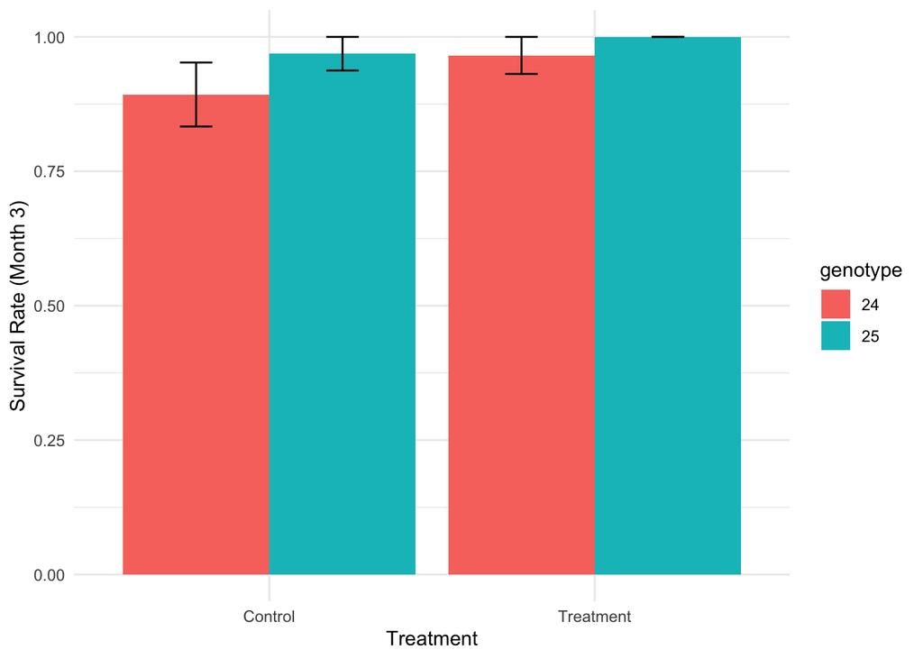

```r
# double check for intermediate survival data
se <- function(x) sd(x, na.rm = TRUE) / sqrt(sum(!is.na(x)))
survival_mo3 <- performance %>%
  group_by(treatment, genotype) %>%
  summarise(survival_rate = mean(survival_mo3),
            survival_se = se(survival_mo3))

ggplot(data = survival_mo3, aes(x = treatment, y = survival_rate, fill = genotype)) +
  geom_col(position = position_dodge()) +
  geom_errorbar(aes(ymin = survival_rate - survival_se, ymax = survival_rate + survival_se), width = .2,
                 position = position_dodge(.9)) +
  ylim(0, 1) +
  labs(y = "Survival Rate (Month 3)", x = "Treatment") +
  theme_minimal()
```

### Models

#### Structure

```r
m_survival_mo3 <- glmer(survival_mo3 ~ treatment + genotype + (1 | table),
             data = performance, family = binomial)
```

**Model:** survival_mo3 ~ treatment + genotype + (1 | table)

#### Performance

```r
car::Anova(m_survival_mo3, type = 3)
```

```
## Analysis of Deviance Table (Type III Wald chisquare tests)
##
## Response: survival_mo3
##              Chisq Df Pr(>Chisq)
## (Intercept) 4.6201  1     0.0316 *
## treatment   0.8362  1     0.3605
## genotype    2.1303  1     0.1444
## ---
## Signif. codes:  0 '***' 0.001 '**' 0.01 '*' 0.05 '.' 0.1 ' ' 1
```

No statistically significant predictors

```r
performance::r2_nakagawa(m_survival_mo3)# marginal/conditional R2 (conditional is without random effects)
```

```
## # R2 for Mixed Models
##
##   Conditional R2: 0.410
##      Marginal R2: 0.224
```

Not bad, but not great predictive power

#### Validity

```r
performance::check_collinearity(m_survival_mo3) # collinearity check for fixed effects
```

```
## # Check for Multicollinearity
##
## Low Correlation
##
##       Term  VIF  VIF 95% CI adj. VIF Tolerance Tolerance 95% CI
##  treatment 1.00 [1.00, Inf]     1.00      1.00     [0.00, 1.00]
##   genotype 1.00 [1.00, Inf]     1.00      1.00     [0.00, 1.00]
```

Good - no collinearity

```r
performance::check_singularity(m_survival_mo3) # check if random effects are identifiable
```

```
## [1] FALSE
```

Good - false means random-effects structure is stable

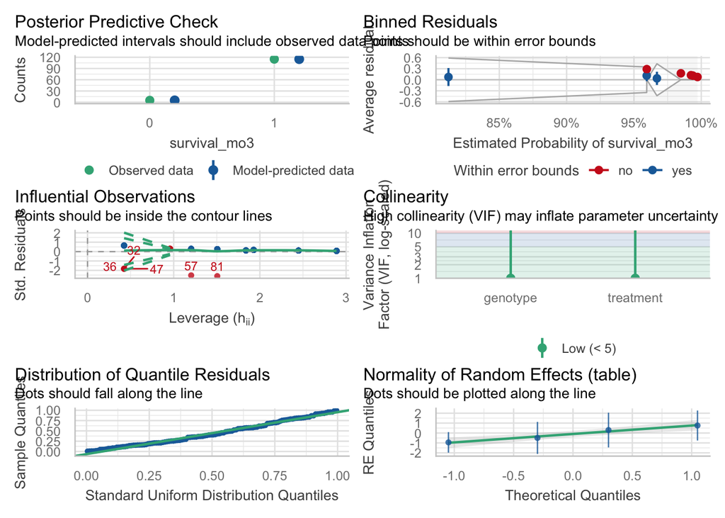

```r
performance::check_model(m_survival_mo3) # diagnostic panel
```

## Month 7

### Visualization

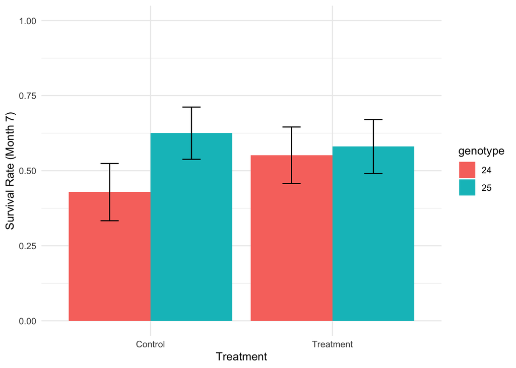

```r
# double check for intermediate survival data
se <- function(x) sd(x, na.rm = TRUE) / sqrt(sum(!is.na(x)))
survival_mo7 <- performance %>%
  group_by(treatment, genotype) %>%
  summarise(survival_rate = mean(survival_mo7),
            survival_se = se(survival_mo7))

ggplot(data = survival_mo7, aes(x = treatment, y = survival_rate, fill = genotype)) +
  geom_col(position = position_dodge()) +
  geom_errorbar(aes(ymin = survival_rate - survival_se, ymax = survival_rate + survival_se), width = .2,
                 position = position_dodge(.9)) +
  ylim(0, 1) +
  labs(y = "Survival Rate (Month 7)", x = "Treatment") +
  theme_minimal()
```

### Models

#### Structure

```r
m_survival_mo7 <- glmer(survival_mo7 ~ treatment + genotype + (1 | table),
             data = performance, family = binomial)
```

**Model:** survival_mo7 ~ treatment + genotype + (1 | table)

#### Performance

```r
car::Anova(m_survival_mo7, type = 3) # Type I/II/III tests available via lmerTest
```

```
## Analysis of Deviance Table (Type III Wald chisquare tests)
##
## Response: survival_mo7
##              Chisq Df Pr(>Chisq)
## (Intercept) 0.1113  1     0.7387
## treatment   0.1521  1     0.6966
## genotype    1.5256  1     0.2168
```

No statistically significant predictors

```r
performance::r2_nakagawa(m_survival_mo7)  # marginal/conditional R2 (conditional is without random effects)
```

```
## Random effect variances not available. Returned R2 does not account for random effects.
```

```
## # R2 for Mixed Models
##
##   Conditional R2: NA
##      Marginal R2: 0.017
```

#### Validity

```r
performance::check_collinearity(m_survival_mo7) # collinearity check for fixed effects
```

```
## # Check for Multicollinearity
##
## Low Correlation
##
##       Term  VIF  VIF 95% CI adj. VIF Tolerance Tolerance 95% CI
##  treatment 1.00 [1.00, Inf]     1.00      1.00     [0.00, 1.00]
##   genotype 1.00 [1.00, Inf]     1.00      1.00     [0.00, 1.00]
```

Good - no collinearity

```r
performance::check_singularity(m_survival_mo7) # check if random effects are identifiable
```

```
## [1] TRUE
```

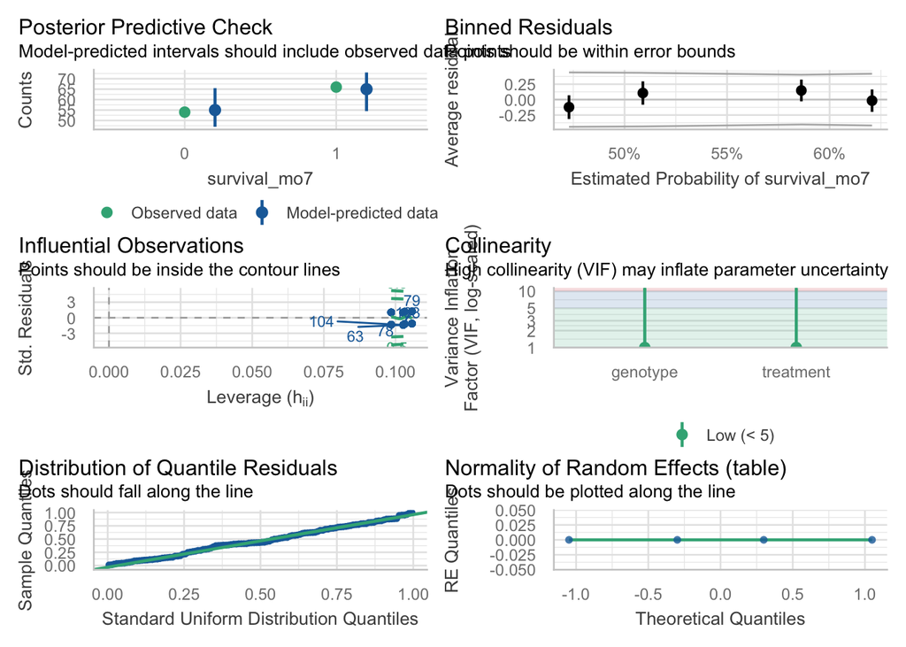

```r
performance::check_model(m_survival_mo7) # diagnostic panel
```